# Spatial Surival analysis with gen expression

Phi Le

# 1 Introduction

Survival analysis is different from other types of data analysis since the unique feature of censors. What is a censor in survival analysis? The short answer is as the following. If a subject does not have an event during the observation time, they are described as censored. The subject is censored in the sense that nothing is observed (subject left the study) or known about that subject after the time of censoring. So, you can see that a usual regression method does not work in the scenario.

Now, we can think a little further. Some people with some types of genes may have an advantage or disadvantage to a certain type of health issue. So it does make sense and reasonable to consider the effects of genes on the survival time of patients.

Next, if you believe that the environment, living conditions, and other social factors could affect the likelihood of recovery of sickness then you may want to add those factors into your models. The easiest one is to use the locations as a general factor for those health determinants if you don’t have all the detailed information you need.

In this note, we will show you how to apply spatial models in survival analysis with gene expression data. Indeed, we will apply the Bayesian paradigm by using the INLA package for R.

# 2 Spatial survival analysis with gene expression in practice

First, we need to load some libraries: You may not need all of them but they are needed for writing complete paper for a scientific journal by rmarkdown

```r
library(tidyverse)
library(INLA)
library(survival)
library(spBayesSurv)
library(Rgraphviz)

library(survminer)
library(survcomp)

library(rgdal)

library(rgeos)

library(maptools)

library(ggplot2)

library(ggalt)

library(ggthemes)

library(ggrepel)

library(RColorBrewer)

library(USAboundaries)

library(sp)

library(spacetime)

library(zoo)

library(sf)

library(spdep)

library(plotly)

library(viridis)
library(cowplot)

library(lemon)
library('latex2exp')
library(kableExtra)
library(knitr)
def.chunk.hook  <- knitr::knit_hooks$get("chunk")
knitr::knit_hooks$set(chunk = function(x, options) {
  x <- def.chunk.hook(x, options)
  ifelse(options$size != "normalsize", paste0("\n \\", options$size,"\n\n", x, "\n\n \\normalsize"), x)
})
```

## 2.1 Loading the data and map

Well, we cannot do any further if there is no data. First thing first, we begin the process by loading the data and the map of regions where patients located.

## 2.2 Getting map data

Getting map information is essential in spatial analysis.

Our data is from Mississippi, so we get our map data for Mississippi by zip code region. To get the map by zip code, you can visit the website https://www2.census.gov/geo/tiger/GENZ2016/shp/ and download the file cb_2016_us_zcta510_500k. In case you don’t know, you can read the map by

```r
example <- readOGR(dsn = "cb_2016_us_zcta510_500k")
```

and filter select the regions you are working on by list of zip code in zip_list

```r
select_region <- subset(example, ZCTA5CE10 %in% zip_list)
```

## 2.3 Loading survival data with patients’coordinate

I have a generated data of survival time and events of patients and their locations

```r
data_new <- read.csv("sur_spatial_data.csv")
data_new
```

| X | ID | OS_time | OS_event | MET | zip | x | y |
| --- | --- | --- | --- | --- | --- | --- | --- |
| 1 | TCGA_2J_AAB1_01A | 2.2000000 | 1 | 11.495526 | 39216 | -90.15288 | 32.34363 |
| 2 | TCGA_2J_AABR_01A | 14.6000000 | 0 | 11.480862 | 39216 | -90.16040 | 32.34145 |
| 3 | TCGA_3A_A9IB_01A | 7.4666667 | 1 | 13.834777 | 39216 | -90.17846 | 32.34055 |
| 4 | TCGA_F2_A7TX_01A | 3.1666667 | 1 | 12.849160 | 39216 | -90.17430 | 32.34189 |
| 5 | TCGA_FB_AAQ0_01A | 15.7666667 | 1 | 11.994088 | 39216 | -90.14511 | 32.33614 |
| 6 | TCGA_HV_AA8V_01A | 30.6666667 | 0 | 10.575746 | 39216 | -90.16699 | 32.34212 |
| 7 | TCGA_HZ_8519_01A | 15.1333333 | 0 | 10.368017 | 39216 | -90.16012 | 32.34137 |
| 8 | TCGA_HZ_A8P1_01A | 0.2333333 | 0 | 11.111382 | 39216 | -90.14593 | 32.33630 |
| 9 | TCGA_IB_7888_01A | 44.4000000 | 1 | 10.616107 | 39216 | -90.17409 | 32.34276 |
| 10 | TCGA_IB_A5ST_01A | 21.1666667 | 0 | 10.814862 | 39216 | -90.15158 | 32.33845 |

[output cut: 140 more lines]

## 2.4 Here is the map and borders of the regions by zip code we are working on. We do not need the zip code border in our analysis (we use continuous spatial model) but it is informative to look at the demographics

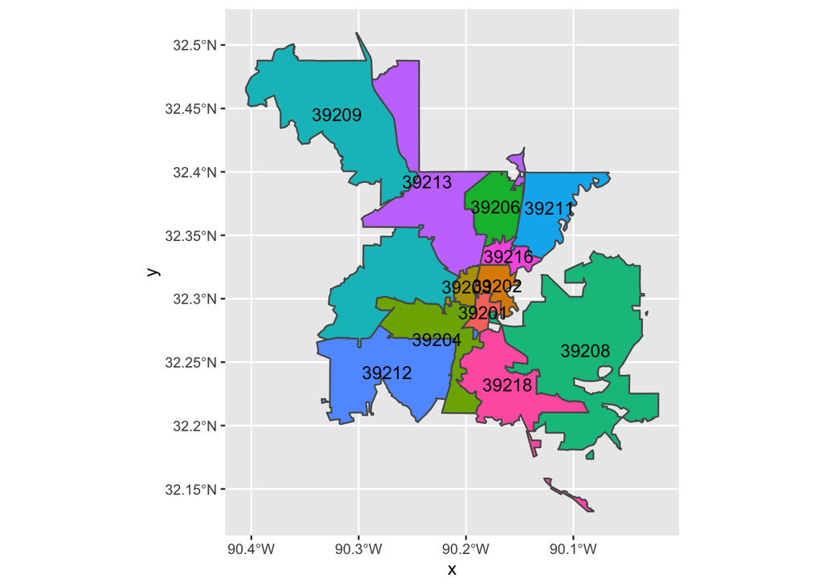

```r
SP_map <- SpatialPolygons(map@polygons, pO = map@plotOrder, proj4string = map@proj4string)

border_map <- rgeos::gUnaryUnion(map)


map_results <- st_as_sf(SP_map)
x_cords <- {}
y_cords <- {}
for (i in c(1:length(SP_map@polygons))){
  x_cords[i] <- SP_map@polygons[[i]]@labpt[1]
  y_cords[i] <- SP_map@polygons[[i]]@labpt[2]
}

coords <- data.frame(x=x_cords, y=y_cords)
coords$zip <- as.numeric(as.character(map$ZCTA5CE10))

ggplot(map_results) + geom_sf(aes(fill = map$ZCTA5CE10)) + geom_text(aes(x,y, label = map$ZCTA5CE10), data=coords)  + theme(legend.position = "none")
```

The following is the positions of patients in the study. The position are generated, so there is no real data.

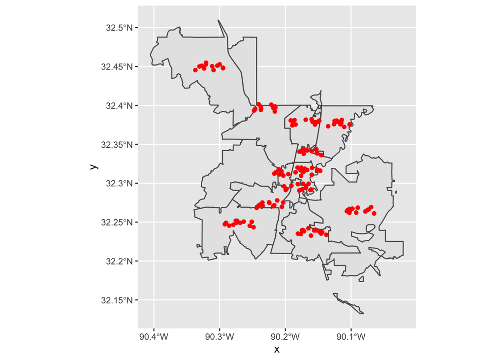

```r
ggplot(map_results) + geom_sf() + geom_point(aes(x=x, y=y), data=data_new, color = "red")
```

# 3 Cox PH Survival analysis with spatial and gene information

Now, we move on to the main part of our work: Data analysis with spatial model for survival analysis with gene expression

## 3.1 KM plot of survival time without spatial effects

Here is the KM plot of the survival data

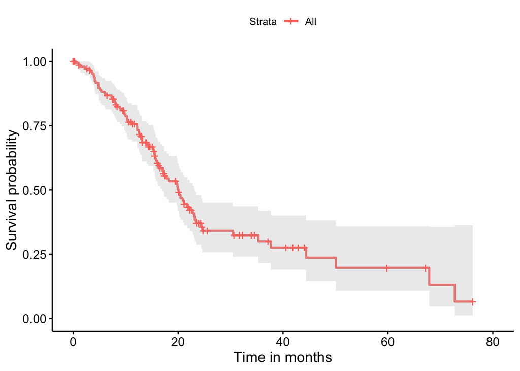

```r
km <- (survfit(Surv(OS_time, OS_event) ~ 1, data_new))
par(mar = c(2.5, 2.5, 0.5, 0.5), mgp = c(1.5, 0.5, 0), las = 1)
ggsurvplot(km, conf.int = TRUE) + xlab("Time in months")
```

We would like to study survival analysis with gene information, so here is our formula. We apply the intercept model with MET variable as a gene expression.

```r
form0 <- inla.surv(OS_time, OS_event) ~ 0 + a0 + MET
```

## 3.2 In INLA we can prepare survival data for fitting a Cox proportional hazard model using the Poisson likelihood using the inla.coxph() function

The following code will help us to find the base line hazard function from our data with out spatial information. The data was interpolated/extrapolated by random walk of degree 1

```r
res_0 <- inla.coxph(form0,
  data = data.frame(a0 = 1, data_new[2:5]),
  control.hazard = list(n.intervals = 25))
```

## 3.3 Now is the technical part, how do we use INLA with Stochastic Partial Differential Equation (spde) method

This is how we create a mesh for out work. The better of the mesh you create, the better result you have. In this tutorial, we just make a mesh that is good enough. Here is how it looks like.

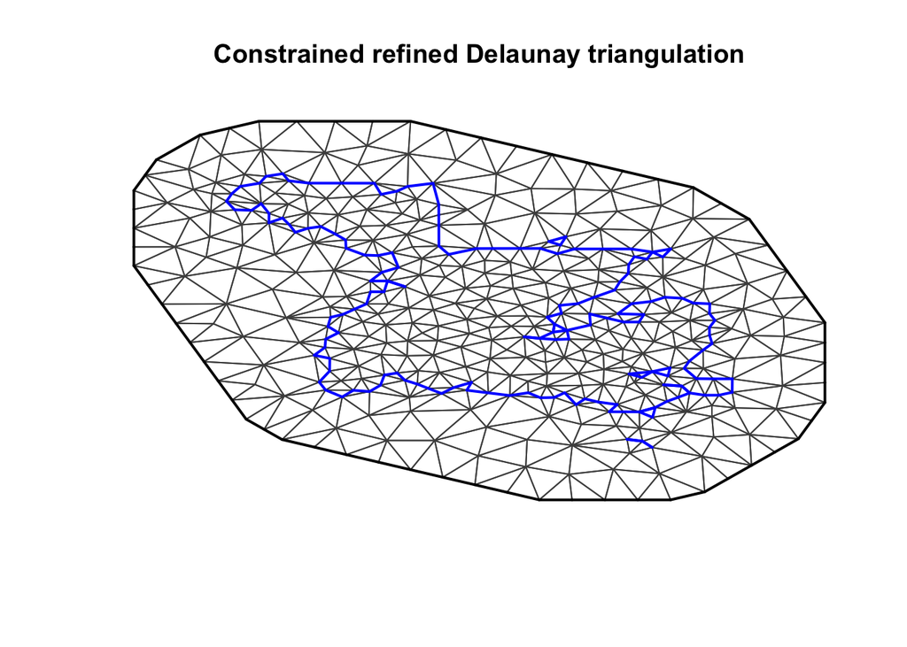

```r
mesh <- inla.mesh.2d(boundary=border_map, loc =as.matrix(coords[1:2]) ,cutoff=0.01, max.edge=c(0.03, 0.05))
plot(mesh)
```

Next, we build a SPDE model with the function inla.spde2.matern, here we chose Laplacian operator (alpha =2)

```r
spde = inla.spde2.matern(mesh, alpha = 2)
```

To work with spatial effect, we need to update the formula with spatial effect

```r
cph.formula <- update(res_0$formula, '. ~ . + f(spatial, model = spde)')
```

A projector matrix is needed for our method. The projector matrix contains the basis function value for each basis, with one basis function at each column. It will be used to interpolate the random field that is being modeled at the mesh nodes.

We build a Projector matrix as the following:

```r
cph.A <- inla.spde.make.A(mesh,
loc = cbind(res_0$data$x, res_0$data$y))
```

The inla.stack() function is useful for organizing data, covariates, indices and projector matrices, all of which are important when constructing an SPDE model.

```r
cph.stk <- inla.stack(
data = c(list(E = res_0$E), res_0$data[c('y..coxph')]), A = list(cph.A, 1),
effects = list(
list(spatial = 1:spde$n.spde),res_0$data[c('baseline.hazard', 'a0', 'MET')]))

cph.data <- c(inla.stack.data(cph.stk), res_0$data.list)
```

# 4 Results

We will compare the results between two models: with spatial effect vs. no-spatial effect

We run a model with spatial random effect with SPDE model. Here the spatial survival analysis model is approximated by Poisson likelihood.

This following paragraph from the book [Advanced Spatial Modeling with Stochastic Partial Differential Equations Using R and INLA](https://becarioprecario.bitbucket.io/spde-gitbook/index.html) explains why we use Poisson likelihood

“This idea was proposed in Holford (1980), detailed in Laird and Olivier (1981) and studied in Andersen and Gill (1982). In INLA we can prepare survival data for fitting a Cox proportional hazard model using the Poisson likelihood using the inla.coxph() function (Martino, Akerkar, and Rue 2010). We supply in this function a formula without the spatial effect, just to have the data prepared for fitting the Cox proportional hazard survival model as a Poisson model. The output from the inla.coxph() function will be supplied in the inla.stack() function together with the spatial terms.”

- With spatial random effect (SPDE model) results

```r
cph.res <- inla(cph.formula, family = 'Poisson',
data = cph.data, E = cph.data$E,
control.predictor = list(A = inla.stack.A(cph.stk)))

cph.res$summary.fixed
```

|  | mean | sd | 0.025quant | 0.5quant | 0.975quant | mode | kld |
| --- | --- | --- | --- | --- | --- | --- | --- |
| a0 | -10.2700087 | 1.5734879 | -13.3753224 | -10.2645836 | -7.1978036 | -10.2536142 | 9.643903e-07 |
| MET | 0.5812064 | 0.1323534 | 0.3213369 | 0.5811994 | 0.8408619 | 0.5811989 | 6.925025e-07 |

- No spatial random effect (SPDE model) result

```r
cph.res0 <- inla(form0, family = 'coxph',
data = data.frame(a0 = 1, data_new))


cph.res0$summary.fixed
```

|  | mean | sd | 0.025quant | 0.5quant | 0.975quant | mode | kld |
| --- | --- | --- | --- | --- | --- | --- | --- |
| a0 | -10.0751186 | 1.5505538 | -13.1319809 | -10.070868 | -7.0449311 | -10.0622956 | 4.235421e-06 |
| MET | 0.5657458 | 0.1299448 | 0.3100723 | 0.565923 | 0.8202035 | 0.5662952 | 5.205660e-08 |

# 5 Summary results comparing with and without SPDE models and without spatial vs. with spatial effect

```r
m0 <- coxph(Surv(OS_time, OS_event) ~ 1 + MET , data_new)
round(data.frame(`CoxPH Only` =(coef(summary(m0))[, c(1,3)]),
NoSpatialEffect = c(cph.res0$summary.fixed[2, 1], cph.res0$summary.fixed[2, 2]),
WithSpatialEffect = c(cph.res$summary.fixed[2, 1], cph.res$summary.fixed[2, 2])),4)
```

|  | CoxPH.Only | NoSpatialEffect | WithSpatialEffect |
| --- | --- | --- | --- |
| coef | 0.5841 | 0.5657 | 0.5812 |
| se(coef) | 0.1334 | 0.1299 | 0.1324 |

There are some differences amongst the results. However, all of them confirm that there is an association between gene MET and survival time of patient. In other words, patient with higher MET gene expression will have higher risk of having an event.